# Course8_Practical_Machine_Learning

assignment

8/1/2017

## 1.Project Overview

One thing that people regularly do is quantify how much of a particular activity they do, but they rarely quantify how well they do it. In this project, our goal is to use data from accelerometers on the belt, forearm, arm, and dumbell of 6 participants to predict the manner in which they did the exercise. This is the “classe” variable in the training set. In a word, we are conducting an supervised learning on this project to predict the testing sample’s class.

#### Background

Using devices such as Jawbone Up, Nike FuelBand, and Fitbit it is now possible to collect a large amount of data about personal activity relatively inexpensively. These type of devices are part of the quantified self movement – a group of enthusiasts who take measurements about themselves regularly to improve their health, to find patterns in their behavior, or because they are tech geeks. One thing that people regularly do is quantify how much of a particular activity they do, but they rarely quantify how well they do it. In this project, the goal will be to use data from accelerometers on the belt, forearm, arm, and dumbell of 6 participants. Six young health participants were asked to perform one set of 10 repetitions of the Unilateral Dumbbell Biceps Curl in five different fashions: exactly according to the specification (Class A), throwing the elbows to the front (Class B), lifting the dumbbell only halfway (Class C), lowering the dumbbell only halfway (Class D) and throwing the hips to the front (Class E).Class A corresponds to the specified execution of the exercise, while the other 4 classes correspond to common mistakes.

Read more: http://web.archive.org/web/20161224072740/http:/groupware.les.inf.puc-rio.br/har#literature#ixzz4obemuLUI

Read more: http://web.archive.org/web/20161224072740/http:/groupware.les.inf.puc-rio.br/har#literature#ixzz4obeTZ7XH

#### Data

The training data for this project are available here: https://d396qusza40orc.cloudfront.net/predmachlearn/pml-training.csv

The test data are available here: https://d396qusza40orc.cloudfront.net/predmachlearn/pml-testing.csv

The data for this project come from this source: http://web.archive.org/web/20161224072740/http:/groupware.les.inf.puc-rio.br/har.

## 2.Executive Summary

### 2.1 Citation

[Thanks sharing from]Velloso, E.; Bulling, A.; Gellersen, H.; Ugulino, W.; Fuks, H. Qualitative Activity Recognition of Weight Lifting Exercises. Proceedings of 4th International Conference in Cooperation with SIGCHI (Augmented Human ’13) . Stuttgart, Germany: ACM SIGCHI, 2013.

Read more: http://web.archive.org/web/20161224072740/http:/groupware.les.inf.puc-rio.br/har#ixzz4obLzpueW

#### 2.2 Execution Steps

According to the project instruction, the project execution should attempt to descripe:

-How you built your mode -how you sued cross validation -what you think the expected out of sample error is -why you made the choices you did

Accordingly, in the project, we conducted the above processes by exploratory data analysis, data processing, fitting models with different agrithms and testing with training data and development data. And finaly we had the best practise, which applied to the final model for the testing data.

## 3.Exploratory Data Analysis

### 3.1 Loading essential packages and set caching in Knitr

```r
library(AppliedPredictiveModeling)
library(caret)
```

```r
library(rpart)
library(rpart.plot)
library(randomForest)
library(ggplot2)
library(knitr)
library(rattle)
knitr::opts_chunk$set(cache = TRUE)
```

### 3.2 Getting and Loading dataset

First of all, we look at the training dataset.

```r
#set.seed for reproducible
set.seed(13425)
#Download and input dataset, use na.strings to covert empty values as NA
training <- read.csv("https://d396qusza40orc.cloudfront.net/predmachlearn/pml-training.csv", header = TRUE, na.strings = c("NA","#DIV/0!",""))
testing <- read.csv("https://d396qusza40orc.cloudfront.net/predmachlearn/pml-testing.csv", header = TRUE, na.strings = c("NA","#DIV/0!",""))
#Check data class to ensure it is data.frame
class(training)
```

```
## [1] "data.frame"
```

```r
#Check data by str() and summary()
#str(training)
#str(testing)
#summary(training)
```

### 3.3 Clearning the dataset

```r
training <- training[, colSums(is.na(training))== 0]
testing <- testing[, colSums(is.na(testing))== 0]

dim(training)
```

```
## [1] 19622    60
```

```r
dim(testing)
```

```
## [1] 20 60
```

```r
#str(training)
names(training)
```

```
##  [1] "X"                    "user_name"            "raw_timestamp_part_1"
##  [4] "raw_timestamp_part_2" "cvtd_timestamp"       "new_window"
##  [7] "num_window"           "roll_belt"            "pitch_belt"
## [10] "yaw_belt"             "total_accel_belt"     "gyros_belt_x"
## [13] "gyros_belt_y"         "gyros_belt_z"         "accel_belt_x"
## [16] "accel_belt_y"         "accel_belt_z"         "magnet_belt_x"
## [19] "magnet_belt_y"        "magnet_belt_z"        "roll_arm"
## [22] "pitch_arm"            "yaw_arm"              "total_accel_arm"
## [25] "gyros_arm_x"          "gyros_arm_y"          "gyros_arm_z"
## [28] "accel_arm_x"          "accel_arm_y"          "accel_arm_z"
## [31] "magnet_arm_x"         "magnet_arm_y"         "magnet_arm_z"
## [34] "roll_dumbbell"        "pitch_dumbbell"       "yaw_dumbbell"
## [37] "total_accel_dumbbell" "gyros_dumbbell_x"     "gyros_dumbbell_y"
## [40] "gyros_dumbbell_z"     "accel_dumbbell_x"     "accel_dumbbell_y"
## [43] "accel_dumbbell_z"     "magnet_dumbbell_x"    "magnet_dumbbell_y"
## [46] "magnet_dumbbell_z"    "roll_forearm"         "pitch_forearm"
## [49] "yaw_forearm"          "total_accel_forearm"  "gyros_forearm_x"
## [52] "gyros_forearm_y"      "gyros_forearm_z"      "accel_forearm_x"
## [55] "accel_forearm_y"      "accel_forearm_z"      "magnet_forearm_x"
## [58] "magnet_forearm_y"     "magnet_forearm_z"     "classe"
```

```r
#names(testing)
```

Split the training set into two sets: training, testing. Note: Both the traing and testing set are under the original training dataset.

```r
cutPonit <- createDataPartition(training$classe, p =0.66, list = FALSE)
modTraining <- training[cutPonit, ]
modTesting <- training[-cutPonit, ]
dim(modTraining)
```

```
## [1] 12953    60
```

```r
#dim(modTesting)
```

```r
#Check for zero variance
czv1 <- nearZeroVar(modTraining, saveMetrics = TRUE)
#czv
modTraining <- modTraining[, czv1$nzv == FALSE]

czv2 <- nearZeroVar(modTesting, saveMetrics = TRUE)
modTesting <- modTesting[, czv2$nzv == FALSE]

colnames(modTraining)
```

```
##  [1] "X"                    "user_name"            "raw_timestamp_part_1"
##  [4] "raw_timestamp_part_2" "cvtd_timestamp"       "num_window"
##  [7] "roll_belt"            "pitch_belt"           "yaw_belt"
## [10] "total_accel_belt"     "gyros_belt_x"         "gyros_belt_y"
## [13] "gyros_belt_z"         "accel_belt_x"         "accel_belt_y"
## [16] "accel_belt_z"         "magnet_belt_x"        "magnet_belt_y"
## [19] "magnet_belt_z"        "roll_arm"             "pitch_arm"
## [22] "yaw_arm"              "total_accel_arm"      "gyros_arm_x"
## [25] "gyros_arm_y"          "gyros_arm_z"          "accel_arm_x"
## [28] "accel_arm_y"          "accel_arm_z"          "magnet_arm_x"
## [31] "magnet_arm_y"         "magnet_arm_z"         "roll_dumbbell"
## [34] "pitch_dumbbell"       "yaw_dumbbell"         "total_accel_dumbbell"
## [37] "gyros_dumbbell_x"     "gyros_dumbbell_y"     "gyros_dumbbell_z"
## [40] "accel_dumbbell_x"     "accel_dumbbell_y"     "accel_dumbbell_z"
## [43] "magnet_dumbbell_x"    "magnet_dumbbell_y"    "magnet_dumbbell_z"
## [46] "roll_forearm"         "pitch_forearm"        "yaw_forearm"
## [49] "total_accel_forearm"  "gyros_forearm_x"      "gyros_forearm_y"
## [52] "gyros_forearm_z"      "accel_forearm_x"      "accel_forearm_y"
## [55] "accel_forearm_z"      "magnet_forearm_x"     "magnet_forearm_y"
## [58] "magnet_forearm_z"     "classe"
```

Remove the first 6 columns in the training set which appear to be less helpful for the modeling.

```r
modTraining <- modTraining[, -c(1:6)]
modTesting <- modTesting[, -c(1:6)]

col1 <- colnames(modTraining)
col2 <- colnames(modTraining[, -53])
modTesting <- modTesting[col1]
testing <- testing[col2]

dim(modTraining)
```

```
## [1] 12953    53
```

```r
dim(modTesting)
```

```
## [1] 6669   53
```

```r
dim(testing)
```

```
## [1] 20 52
```

## 4. Building Supervised Learning Model

### 4.1 Predicting with Decision Trees

#### 4.1.1 Model with Recursive Partitioning Trees

```r
set.seed(13425)

# Use the rpart function to build a classification tree model:
modFit1 <- rpart(classe~., data = modTraining, method = "class")

# Retrieve the node detail of the classification tree:
modFit1
```

```
## n= 12953
##
## node), split, n, loss, yval, (yprob)
##       * denotes terminal node
##
##    1) root 12953 9270 A (0.28 0.19 0.17 0.16 0.18)
##      2) roll_belt< 130.5 11860 8184 A (0.31 0.21 0.19 0.18 0.11)
##        4) pitch_forearm< -34.6 1029    5 A (1 0.0049 0 0 0) *
##        5) pitch_forearm>=-34.6 10831 8179 A (0.24 0.23 0.21 0.2 0.12)
##         10) magnet_dumbbell_y< 438.5 9139 6539 A (0.28 0.18 0.24 0.19 0.11)
##           20) roll_forearm< 123.5 5667 3337 A (0.41 0.18 0.18 0.17 0.058)
##             40) magnet_dumbbell_z< -27.5 1898  613 A (0.68 0.21 0.014 0.074 0.026) *
##             41) magnet_dumbbell_z>=-27.5 3769 2724 A (0.28 0.17 0.26 0.22 0.073)
##               82) accel_dumbbell_y>=-40.5 3312 2272 A (0.31 0.19 0.18 0.24 0.077)
##                164) yaw_belt>=169.5 465   58 A (0.88 0.056 0 0.067 0.0022) *
##                165) yaw_belt< 169.5 2847 2075 D (0.22 0.21 0.21 0.27 0.089)
##                  330) pitch_belt< -42.95 351   66 B (0.017 0.81 0.091 0.046 0.034) *
##                  331) pitch_belt>=-42.95 2496 1740 D (0.25 0.13 0.22 0.3 0.097)
##                    662) roll_belt>=125.5 568  246 C (0.4 0.018 0.57 0.0088 0.0053)
##                     1324) magnet_belt_z< -326.5 198    3 A (0.98 0 0 0 0.015) *
##                     1325) magnet_belt_z>=-326.5 370   48 C (0.089 0.027 0.87 0.014 0) *
##                    663) roll_belt< 125.5 1928 1177 D (0.21 0.16 0.12 0.39 0.12)
##                     1326) yaw_belt< -87.05 1093  798 A (0.27 0.25 0.15 0.2 0.13)
##                       2652) yaw_forearm>=-94.9 862  567 A (0.34 0.29 0.15 0.064 0.15)
##                         5304) magnet_forearm_z>=-48 376  104 A (0.72 0.15 0.008 0.032 0.088) *
##                         5305) magnet_forearm_z< -48 486  288 B (0.047 0.41 0.25 0.088 0.21) *
##                       2653) yaw_forearm< -94.9 231   68 D (0 0.082 0.16 0.71 0.048) *
##                     1327) yaw_belt>=-87.05 835  302 D (0.12 0.04 0.084 0.64 0.11)
##                       2654) yaw_arm< -102.85 97    1 A (0.99 0 0.01 0 0) *
##                       2655) yaw_arm>=-102.85 738  205 D (0.011 0.045 0.093 0.72 0.13) *
##               83) accel_dumbbell_y< -40.5 457   59 C (0.011 0.042 0.87 0.028 0.048) *
##           21) roll_forearm>=123.5 3472 2299 C (0.078 0.17 0.34 0.23 0.18)
##             42) magnet_dumbbell_y< 292.5 2078 1067 C (0.092 0.13 0.49 0.15 0.14)
##               84) magnet_forearm_z< -255.5 166   32 A (0.81 0.06 0 0.036 0.096) *
##               85) magnet_forearm_z>=-255.5 1912  901 C (0.03 0.13 0.53 0.16 0.15) *
##             43) magnet_dumbbell_y>=292.5 1394  912 D (0.057 0.24 0.12 0.35 0.24)
##               86) accel_forearm_x>=-101.5 893  595 E (0.049 0.31 0.16 0.14 0.33)
##                172) magnet_arm_y>=188.5 374  166 B (0.008 0.56 0.22 0.1 0.11) *
##                173) magnet_arm_y< 188.5 519  261 E (0.079 0.14 0.12 0.17 0.5) *
##               87) accel_forearm_x< -101.5 501  146 D (0.07 0.12 0.034 0.71 0.07) *
##         11) magnet_dumbbell_y>=438.5 1692  836 B (0.031 0.51 0.044 0.22 0.2)
##           22) total_accel_dumbbell>=5.5 1219  435 B (0.043 0.64 0.059 0.018 0.24)
##             44) roll_belt>=-0.575 1018  234 B (0.051 0.77 0.071 0.022 0.086) *
##             45) roll_belt< -0.575 201    0 E (0 0 0 0 1) *
##           23) total_accel_dumbbell< 5.5 473  120 D (0 0.15 0.0042 0.75 0.097) *
##      3) roll_belt>=130.5 1093    7 E (0.0064 0 0 0 0.99) *
```

```r
# Use the printcp function to examine the Cost Complexity Parameter:
printcp(modFit1)
```

```
##
## Classification tree:
## rpart(formula = classe ~ ., data = modTraining, method = "class")
##
## Variables actually used in tree construction:
##  [1] accel_dumbbell_y     accel_forearm_x      magnet_arm_y
##  [4] magnet_belt_z        magnet_dumbbell_y    magnet_dumbbell_z
##  [7] magnet_forearm_z     pitch_belt           pitch_forearm
## [10] roll_belt            roll_forearm         total_accel_dumbbell
## [13] yaw_arm              yaw_belt             yaw_forearm
##
## Root node error: 9270/12953 = 0.71566
##
## n= 12953
##
##          CP nsplit rel error  xerror      xstd
## 1  0.116397      0   1.00000 1.00000 0.0055383
## 2  0.061381      1   0.88360 0.88360 0.0059197
## 3  0.034520      4   0.69946 0.70367 0.0061385
## 4  0.030313      5   0.66494 0.67389 0.0061348
## 5  0.021683      6   0.63463 0.63614 0.0061141
## 6  0.021197      7   0.61294 0.59223 0.0060671
## 7  0.021036     12   0.49234 0.54639 0.0059911
## 8  0.018447     13   0.47131 0.47346 0.0058111
## 9  0.018123     14   0.45286 0.46289 0.0057786
## 10 0.014923     15   0.43474 0.44261 0.0057116
## 11 0.014455     18   0.38997 0.41640 0.0056154
## 12 0.010356     19   0.37551 0.40097 0.0055536
## 13 0.010000     20   0.36516 0.37454 0.0054382
```

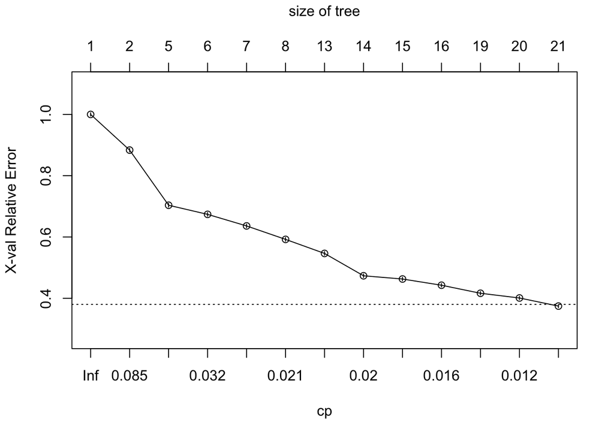

```r
plotcp(modFit1)
```

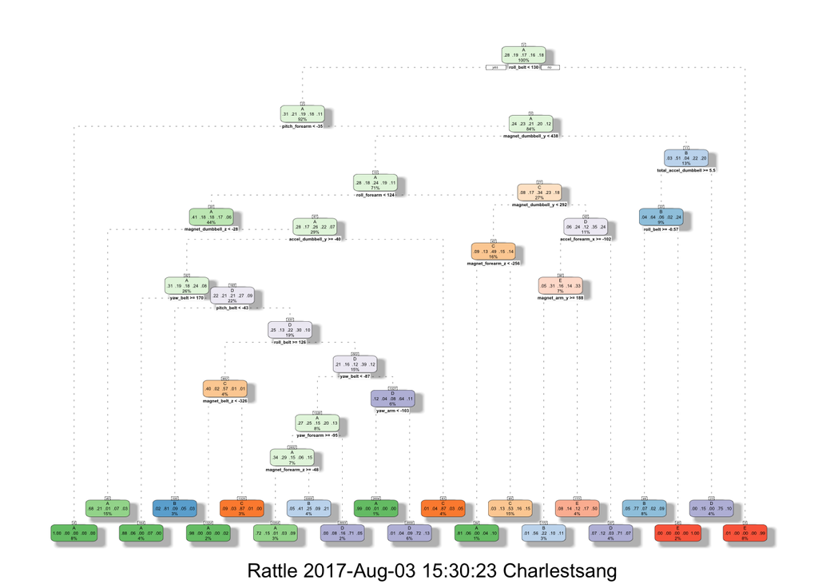

```r
#summary(modFit1)

# Use the fancyRpartPlot function and the text function to plot the classification tree:
fancyRpartPlot(modFit1)
```

[figure not shown]

```r
par(xpd = TRUE)
plot(modFit1, uniform= TRUE, branch=1, margin = 0.05)
text(modFit1, all = TRUE, use.n = FALSE)
```

```r
# Use the predict function to generate a predicted label of the testing data
predM1 <- predict(modFit1, modTesting, type = "class")

# Use the table function to generate a classification table for the testing data:
table(modTesting$classe, predM1)
```

```
##    predM1
##        A    B    C    D    E
##   A 1717   65   66   22   27
##   B  262  717  158  104   49
##   C   14  167  884   72   26
##   D  105   60  158  717   53
##   E   59  142  151  113  761
```

```r
# Use the confusionMatrix function from the caret package for more predicted information:
conMat <- confusionMatrix(predM1, modTesting$classe)
conMat
```

```
## Confusion Matrix and Statistics
##
##           Reference
## Prediction    A    B    C    D    E
##          A 1717  262   14  105   59
##          B   65  717  167   60  142
##          C   66  158  884  158  151
##          D   22  104   72  717  113
##          E   27   49   26   53  761
##
## Overall Statistics
##
##                Accuracy : 0.7191
##                  95% CI : (0.7082, 0.7299)
##     No Information Rate : 0.2845
##     P-Value [Acc > NIR] : < 2.2e-16
##
##                   Kappa : 0.6432
##  Mcnemar's Test P-Value : < 2.2e-16
##
## Statistics by Class:
##
##                      Class: A Class: B Class: C Class: D Class: E
## Sensitivity            0.9051   0.5558   0.7601   0.6560   0.6207
## Specificity            0.9078   0.9193   0.9032   0.9442   0.9715
## Pos Pred Value         0.7960   0.6229   0.6239   0.6975   0.8308
## Neg Pred Value         0.9601   0.8962   0.9469   0.9333   0.9192
## Prevalence             0.2845   0.1934   0.1744   0.1639   0.1838
## Detection Rate         0.2575   0.1075   0.1326   0.1075   0.1141
## Detection Prevalence   0.3234   0.1726   0.2125   0.1541   0.1374
## Balanced Accuracy      0.9065   0.7376   0.8316   0.8001   0.7961
```

So far, we find the the first recursive partitioning tree accuracy is 0.7191, which is still quite low comparing to our benchmark accuracy of over 0.99. Since the recursive partitioning tree is prone to bias and over-fitting. Let’s try to use cost complexity pruning method to prune the classification tree.

```r
# Find the minimum cross-validation error of the classification tree mode:
min(modFit1$cptable[, "xerror"])
```

```
## [1] 0.3745415
```

```r
# Locate the record with the minimum cross-validation errors:
which.min(modFit1$cptable[, "xerror"])
```

```
## 13
## 13
```